# discretasApuntes

Titulo : Apuntes de clases, estructuras discretas EIF203

Autor : Karla Verónica Quirós Delgado

NRC : 41711

Grupo : 8 am

Profesor: Carlos Loria Saénz

<sub>Fecha: 10/03/22</sub>

# Analisis de algoritmos:

## Algoritmo:

Forma de resolver computacionalmente un problema.

## Seudo-código:

forma semiformal de un programa, de manera genérica para dar una idea de como es el algoritmo, no especificamente.

### Pasos para resolver un algoritmo:

1) Establecer el tamaño "n" de los datos.

2) Determinar las operaciones relevantes.

3) Establecer la recurrencia para la ecuación TA(n), tomar el peor de los casos.

4) Resolver la ecuación TA(n) eliminando la recurrencia, usando sustitución.

5) Determinar el orden de crecimiento asintótico.

6) Recopilar información empirica.

<sub>Fecha: 14/03/22</sub>

### Apuntes de python importantes:

Sintaxis : ¿Que y como lo escribo?

Sémantica: ¿Que significa?

### Aspectos importantes:

1) Datos: todo objeto tiene un tipo de dato, números: (int, float), string, listas, bool(True,False)

2) None : es el nullptr de c++

3) Operaciónes: Expresiones(datos, valores)

4) Estatutos: while, for, if, asiganción.

5) Lista, array dinámico(vector), es más lenta que un array y gasta más tiempo.

```python
#karla Quiros
a = [12, 34 , 20, 17, 10]
x = 34
desde:int = 0
hasta = 4

#0
def buscar_while_desde(x:int, a:[int], desde:int, hasta:int) -> int:

    while desde < len(a):
        if x == a[desde]:
            return desde
        else:
            desde += 1 #continue buscando

    return -1
print ( f"la primera posicion de x={x} en la lista a={a} es {buscar_while_desde(x,a,desde,hasta)}")

#1

def buscar_index(x:int,a:[int])-> int:

    try:
        lst = a.index(x)
    except:
         lst = -1
    return lst

print ( f"la primera posicion de x={x} en la lista a={a} es {buscar_index(x,a) }")

#2

def buscar_while_desd(x:int, a:[int], desde:int, hasta:int) -> int:

    if (desde>hasta):
        print(f"la primera posicion de x se busco de derecha a izquierda")
        while desde>hasta:
            if x==a[desde]:

                return desde

            desde=desde-1
    else:
        while desde<hasta:
            if x==a[desde]:
                print(f"la primera posicion de x se busco de izquierda a derecha")
                return desde
            desde+=1
    return -1

#3

def buscar_for_desde(x:int, a:[int],desde,hasta)-> int:
    if(desde<hasta):
        for desde in range(hasta):
            if x==a[desde]:
                print(f"la primera posicion de x se busco de izquierda a derecha")
                return desde
    else:
        for hasta in reversed(range(desde+1)):
            if hasta!=len(a)+1:
                if x==a[hasta]:
                    print(f"la primera posicion de x se busco de derecha a izquierda")
                    return hasta
    return -1

print(buscar_while_desd(x,a,desde,hasta))
print(buscar_for_desde(x,a,desde,hasta))
```

```
la primera posicion de x=34 en la lista a=[12, 34, 20, 17, 10] es 1
la primera posicion de x=34 en la lista a=[12, 34, 20, 17, 10] es 1
la primera posicion de x se busco de izquierda a derecha
1
la primera posicion de x se busco de izquierda a derecha
1
```

<sub>Fecha: 17/03/22</sub>

## Criterios de calidad:

1) Usabilidad: Fácilidad de uso.

2) Correctitud: La funcionalidad es la esperada.

3) Rendimiento: Uso eficiente de recursos, tiempo y memoria.

4) Mantenibilidad: Capacidad de evolucionar ante cambios.

5) Reuso / Extensibilidad

## Operaciones de tiempo constantes:

Ejemplo: += toma 0.27 y es constante.

## Operaciones de tiempo no constante:

Lista: a = []

a.append(x)

[figure not shown]

Por lo tanto el insertar en una lista, no toma tiempo constante. Factor de crecimiento 100*1.25

Len(a) si es constante porque sabe cuantos elementos tiene.

<sub>Fecha: 21/03/22</sub>

### Operadores:

'*' 0.026 v

'+' 0.020 v

'-' 0.020 v

'/' 0.026 v

Cuando el tiempo es mas grande, es mas cara.

Si 'A' es de tiempo constante, decimos que es O(1)

[figure not shown]

Pasa una línea recta y demostramos que el algoritmo esta debajo de la constante. Se dice entonces que es O(1).

∃ c > 0 TA(n) <=c

El tiempo de la multiplicacion, sin importar el # que múltiplique siempre es tiempo O(1).

T * (n) ~ O(1)

T + (n) ~ O(1)

Tlen (n) ~ O(1)

```python
def buscar(x:int, a:list[int])-> int:
    p: int =0
    while p < len(a):
        if x == a[p]:
            return p
        else: p += 1
    return -1
a = [2,1,4]
print(buscar(4, a))
```

```
2
```

### Analisis de 6 pasos para método anterior:

1) Paso 1: tamaño de datos (n), n = len(a)

2) Paso 2: Operaciones de interes: =, <, ==, len , [], += supuesto que todas toman tiempo O(1)

3) Paso 3: Ecuación de Tbuscar(n)

Tbuscar(n) = si n = 0 y a = vacio

```
            1+1+1 = 3tiempo = < len
            si n > 0 , 3 (2 por cada vez que entra al ciclo, 2 + 1 = 3, 2 del if y 1 de +=)
Tbuscar(n)

           {
              5n

            5 + Tbuscar(n-1)}
```

Paso 4: eliminar recurrencia

```
  Tbuscar(3) = 2+1+1+1+ Tbuscar(2)

  = 5 + Tbuscar(2)
  = 5 + 5 + Tbuscar(1)
  = 10 + Tbuscar(1)
  = 10+5 + Tbuscar(0)
  = 15 + Tbuscar(0)
```

Tbuscar(n) = 5n

Tbuscar(n) = 5n+ 2 +1 = 5n+3

Paso 5: Orden crecimiento O(n), lineal

Paso 6: (Grafica)

Nota: si un método tiene dos for cada for toma O(n), por lo que tendra O(n^2)

<sub>Fecha: 24/03/22</sub>

### Principio de pareto:

Permite centrarse en aquellos factores que tendran mayor impacto si son mejorados, logrando una mejor canalización.

### autoestudio es simetrica revision

```python
def es_simetrica(a:list[list[int]]) -> bool:
    for i in range(len(a)-1) :# el rango de i inicia
        for j in range(i+1,len(a)) :# el rango de j va ir siendo 1 mayor que cada i, se va ignorando la diagonal
            try:
                if a[i][j] != a[j][i] :# si no es simetrica
                    return [i,j]
            except:
                return "la matriz no es nxn"
    return True
a =[[2,2,2],[3,3,3]]
b =[[3,-4],[-4,3]]
print(es_simetrica(b))
print(es_simetrica(a))
```

```
True
[0, 1]
```

### Analisis:

Paso 1: n = n<sup>2</sup>

Paso 2: !=, [], len

Paso 3: Tes_simetrica(n)

```
             = 0 si n = 0

             = 5(n-1) + Tes_simetrica(n-2), si n>0
```

Paso 4: eliminar recursión

```
    Tes_simetrica(n)
                     = 5(n-1) + 5 (n-2) +Tes_simetrica(n-2)
                     = 5(n-1) + 5(n-2)+5(n-3)+ Tes_simetrica(n-3)
                     = 5(n-1) + 5(n-2)+5(n-3)+ ......+
                     = 5(n-1) + 5(n-2)+5(n-3)+ ....+ 5x2+5x1
                     = 5((n-1)+ 5(n-2)+....+2+1)
                     = 5(((n-1)n/)2) =5n^2/2 - 5n/2
                     = m(m+1)/2
```

Paso 5: O(n<sup>2</sup>)

<sub>Fecha: 28/03/22 y 31/03/22</sub>

### Oh-grande

[figure not shown]

Una función que no es constante, no se puede determinar tan rápido.

Analisis asintótico = n -> ∞, cuando n es grande interesa

Ejemplo: f(n) = 20n<sup>2</sup> + 500

n<sup>2</sup> domina la función, n<sup>2</sup> sola no es mayor o igual que 20 n<sup>2</sup> + 500, pero si multiplica una constante por n<sup>2</sup> , si es más grande.

Mejora no esencial: si mejora un algoritmo solo por constante.

Esencial: Son mejores dominantes.

### Relaciones de recurrencia

Recursividad: Figura que tiene dentro de si una misma figura pero mas pequeña. (copias de si mismo dentro) Las funciones recursivas consumen más recursos en tiempo y memoria, por ende son ineficientes.

[figure not shown]

Tbuscar es un ejemplo recursivo, porque para saber su tiempo necesita, el tiempo del anterior. Para resolver casos recursivos, la estrategia es resolver el caso base (pequeño).

#### caso base:

Es el caso en que la función ya no tiene recurrencia.

#### Orden de la recurrencia

El orden de recurrencia esta basado al número de veces que una función se llama asi misma.

Ejemplo: codigo de método fibonacci recursivo.

```python
def fibo(n):#recursiva(hacia atras)
    if n<= 1:
        return 1
    return fibo(n-1) + fibo(n-2)


print(fibo(4))
```

```
5
```

Ejemplo: codigo fibonacci iterativo

```python
def fibo_iter(n):# iterativa ya sea for, while etc
    a, b = 1, 1 # tuple python
    for k in range(n):
        a, b = b, a+b # primer valor se lo asigna a a
    return a
print(fibo_iter(4))
```

```
5
```

Pila: (stack), lista donde solo puede insertar y buscar al final de la lista.

Push: insertar

Pop: sacar

Ejemplo 2: función que trabaja en conjunto con otra.

```python
def f(x):
    return g(x+1) + 10
def g(x):
    return x+2
print(f(3))
```

```
16
```

Ejemplos de codigos recursivos y iterativos de clase

```python
def f(x):
    def g(x):
        return x+1
    return g(x+1) +666
def p(x):
    return (2*x, x**2)# tuple
def sumar(a:list[int])-> int:
    if a == []:
        return 0
    return a[0] + sumar(a[1:])

def sn_recursivo(n):
    if n == 0: return 2
    return 5 * sn_recursivo(n-1) + 3

def sn_formula(n):
    return ( 11 * 5 ** n-3) // 4 # el doble // es para dividir y dar un resultado en entero
print(f(5))
print(sumar([2,4,5]))
print(sn_recursivo(5))
print(sn_formula(5))
```

```
673
11
8593
8593
```

### Formas de resolver una RR

#### Sustitución hacia atras:

Se inicia resolviendo el último n obtenido hasta llegar al caso base(donde no hay mas recursión).

#### Sustitución hacia adelante:

Se inicia resolviendo el caso base, hasta llegar a resolver(forma de tabla).

Nota: Forwards(ascendente), backwards(descendente).

Ejemplo: sustitución hacia adelante

Teniendo sn

```
        = 1, si n=0 (caso base)

        = n*sn-1, si n>0
```

Ejemplo: sustitución hacia atras (factorial)

s4 =

```
4*s3 = 4(3s2)

     = 4(3(2s1))

     = 4(3(2(1s0)))

     = 4(3(2 * 1))

     = 4(3 * 2)

     = 4 * 6

     = 24
```

sustitución hacia adelante (factorial):

[figure not shown]

<sub>Fecha: 04/04/22</sub>

### Definición O-grande

[figure not shown]

creaciones propias basadas en apuntes de clase.

### HLCC(2) RR

#### caracteristicas:

1) Tiene a lo más 2 llamadas(orden 2)

2) Solo multiplicar por constantes(cc = coeficientes constantes)

3) Solo sumando(lineal), no hay carculos esperando llamdas recursivas.

4) Teorema : Se utilizan cuando la recursion se da fn = fn-1 + fn-2, cuando suamn tiempos anteriores.

#### Ejemplo: fibinacci HLCC(2)

fn = 1fn-1 + 2 fn-2...... Cumple las restricciones del teorema, porque la constante multiplica al tiempo y al final se suman. No hay nada esperando. HLCC(2) = homogeneo, lineal, coeficiente, constantes, grado 2.

#### Ejemplos no HLCC(2)

1) fn = 2fn/2 + 1

No es HLCC porque de n pasa a n/2, no es lineal

2) fn = nfn-1+2fn-2

n multiplica la llamada recursiva y n no es constante.

### Pasos para resolver una HLCC(2)

1) Resolver polinomio caracteristico

2) Encontrar las raices

```
si r1 != r2 = αr1<sup>n</sup> +  βr2<sup>n</sup> α, β constantes, para todo n >= 0
depende de f0 y f1

si r1 == r2 = r =  αr<sup>n</sup> +  βr<sup>n</sup> α, β constantes, para todo n >= 0
```

Codigos de clase:

Ejemplo resolucion por HLCC(2)

```python
def exp_recursivo(x, n):
    if n == 0:
        return 1
    return x * exp_recursivo(x, n-1)

    def test_exp(times = 10):

     for i in range(times):
        print(n, exp_recursivo(2, n), exp_iter(2, n))

    test_exp()

def exp_iter(x, n):
    res = 1
    for k in range (n):
        res *= x
    return res
```

```python
def f(n):
    if n == 0:
        return
    if n == 1:
        print("viva el team")
        return
    f(n-1)
    for i in range(1, 3):
        f(n-2)
print(f(3))
```

```
viva el team
viva el team
viva el team
None
```

### Resolver por HLCC(2)

```
  sn = -sn-1
  s0 = -1
```

Resolver

```
Pc(x)  =
```

x<sup>2</sup> + x + 0

=x<sup>2</sup> + x

= x(x+1) factorizar

= 0 y -1

r1= 0 y r2 = -1

fn = a 0<sup>n</sup> + b - 1<sup>n</sup>

fn = b-1<sup>n</sup>

f0= b-1<sup>0</sup> --> = b

b = -1

fn= b-1<sup>n</sup> --> -1(-1)<sup>n</sup>

fn = -1(-1<sup>n</sup> )

O~(-1)<sup>n</sup>

<sub>Fecha: 08/04/22 1°Examen</sub>

<sub>Fecha: 12/04/22</sub>

### Hanoi

Consta en mover discos de una posición A a una posición C, usando los siguientes pasos:

1) Mover uno ala vez.

2) Se debe mover el disco que este en la cima (el que esta por encima de los demas).

3) Los discos grandes tienen colocados encima discos mas pequeños.

[figure not shown]

Ejercicio codigo Hanoi

```python
def Hanoi(n, A = 'A', B = 'B', C= 'C'):
    if n == 1:
        print(f"Mueva de{A} a {C}")
        return
    Hanoi(n-1, A, C, B)
    print(f"Mueva de{A} a {C}")
    Hanoi(n-1, B, A, C)
print(Hanoi(2))
```

```
Mueva deA a B
Mueva deA a C
Mueva deB a C
None
```

### D y C (divide y conquistaras)

Consta en tomar un problema y dividirlo en problemas iguales.

Ejemplo:

[figure not shown]

```python
#DyC
def sumDyC(a:list[int]) -> int:
    if len(a) == 1:  return a[0] # returna 0 porque si es un elemento no puede subdividirse en dos, es el caso base
    divide = len(a)// 2    # tomamos el tamnio de la lista
    return sumDyC(a[0: divide]) + sumDyC(a[divide:]) # subdividimos el problema en dos mitades, hasta que ya no se pueda subdividir
                                                         #y unimos el resultado de ambas mitades consecutivamente
a = [2,3,4]
print(sumDyC(a))
```

```
9
```

Ejemplo: merge

```python
def merge(a, b):
    n, m = len(a), len(b)
    result = [0] * (n+m)
    i, j, k = 0, 0, 0;

    while i < n and j < m:
        if a[i]< b[j]:
            result[k] = a[i]
            i += 1
        else:
            result[k] = b[j]
            j += 1
        k += 1
    while i < n:
        result[k] = a[i]
        i += 1
        k += 1
    while j < m:
        result[k] = b[j]
        j += 1
        k += 1
    return result

a = [10, 15, 16]
b = [1, 2, 14, 25, 26, 30]
print(merge(a, b))
```

```
[1, 2, 10, 14, 15, 16, 25, 26, 30]
```

```python
def bubble(a):
    for limit in range (len(a), 0, -1):
        for i in range (limit -1):
            if a[i] > a[i + 1]:
                a[i], a[i+1] = a[i + 1], a[i]
    return a

a = [2, 3, 5, -6, -7]
print(bubble(a))
def bubble_instrumentado(a):
    cont = 0
    for limit in range (len(a), 0, -1):
        for i in range (limit -1):
            if a[i] > a[i + 1]:
                a[i], a[i+1] = a[i + 1], a[i]
                cont += 2
    return cont
```

```
[-7, -6, 2, 3, 5]
```

```python
#practicas
def quickSort(a:list[int],izquierda, derecha) -> int:
    if izquierda < derecha:
        mitad = particion(a, izquierda, derecha)
        quickSort(a, izquierda, mitad)
        quickSort(a, mitad + 1, derecha)


def particion(a:list[int],izq,derec) -> int:
    pivote = a[izq]
    while True:
        while a[izq] < pivote:
            izq += 1
        while a[derec] > pivote:
            derec -= 1
        if izq >= derec:
            return derec
        else:
            a[izq], a[derec] = a[derec], a[izq]
        izq  += 1
        derec -= 1

a = [5, 1, 2, 1, 1, 3, 5, 1, 5, 1, 99, 231, 234, 12, 121 ]
print("Antes de ordenarlo: ")
print(a)
quickSort(a, 0, len(a) - 1)
print("Después de ordenarlo: ")
print(a)
```

```
Antes de ordenarlo:
[5, 1, 2, 1, 1, 3, 5, 1, 5, 1, 99, 231, 234, 12, 121]
Después de ordenarlo:
[1, 1, 1, 1, 1, 2, 3, 5, 5, 5, 12, 99, 121, 231, 234]
```

## Formalización asintótica: O(), Ω(), Θ()

O() f ~ O(g) -> ∃ n0 >= 0, ∃ c > 0 : f(n) <= cg(n) ∀ n >= n0

Una función g multiplicada por una constante en un punto (n0) es >= a f.

Se concluye que f crece a lo más como g basado por una constante

Ω() f ~ Ω(g) -> g ~ O(f)

Una función g multiplicada por una constante g sea < f basado en un punto n0.

Se concluye que f crece al menos como g basado por una constante, f >= cg

Θ() f ~ Θ(g) -> f ~ Ω(g) ^ f ~ O(g)

Una función que al probar los dos casos, tiene una cota O(g) y Ω(g) al mismo tiempo, dandose dos funciones g, con constantes diferentes y diferentes puntos n0.

#### Teoremas importantes

1) c ~ O(1) ∀ c > 0

2) f1 + f2 ~ O( max(f1, f2) )

3) f1 * f2 ~ O( O(f1), O(f2) )

4) si es un polinomio, f ~ O(nd), se usa al monomio más grande

## Orientacion a objetos en python

```python
class Animal:
    def __init__(self, name:str): # self es como this en c++, este metodo es como constructor
        self.name = name
    def __repr__(self):#info general
        return f"Animal(name={self.name})"
    def __str__(self):#tostring de python
        return self.name
    def eat(self, food):
        print(f"{self.name} is eating {food}")
    def __eq__(self, other): #eq es un dunder q se asocia con ==
        if self is other:return True #is ve si es el mismo puntero
        if isinstance(other, Animal):
            return self.name == other.name
        return False
        # pass #
#pruebas
a = Animal('charlie')
print(a)
a.eat('apple')

class Dog(Animal):
    pass
doggy = Dog('doggy')
anotherdog = Dog('doggy')
```

```
charlie
charlie is eating apple
```

### Propiedades Relaciones Binarias:

Reflexiva: ∀ x / xRx para todo x se tiene que x esta relacionado con si mismo.

[figure not shown]

issubclass es reflexiva

Simétrica: ∀ x,y / xRy → yRx, para cuales quiera de dos elementos se tiene que si x se relaciona con y, y tiene que relacionarse con x para ser simétrica.

[figure not shown]

Transitiva: ∀ x,y,z / xRy ^ yRz → xRz, se tiene que si x se relaciona con y, Y y se relaciona con z, entonces x esta relacionado con z. Donde no necesariamente son elementos diferentes.

[figure not shown]

Equivalencia: Es reflexiva, simétrica y transitiva.

Irreflexiva : ∀ x / x¬Rx, x no está relacionado consigo mismo.

Antisimétrica: ∀ x,y / ∀ x,y /xRy ^ yRx → x = y, x está relacionado con y, ^ y está relacionado con x, siendo x ^ y el mismo elemento.

Orden Parcial: Reflexiva, antisimétrica y transitiva.

### Diccionarios:

Crean una función hash que toma un objeto y le aplica un calculo matematico, para convertirlo en un entero. Debe haber una baja probabilidad de que dos elementos tengan el mismo hash.

```python
dic = {'csh':28,'darissa':35,'lda':30,'csc':3}
print(dic['csh'])
dic['csh'] += 1
```

```
28
```

### Relaciones de equivalencia y clases de equivalencia

Si agrupamos los elementos con equivalencia, solo tendriamos que revisar uno por grupo y asi sabriamos la información de los demas equivalentes a este.

#### caracteristicas:

1) Son disjuntos: no comparten caracteristicas entre grupos diferentes.

2) Unión de todas las clases.

3) Las clases no pueden ser vacias, porque tienen reflexividad.

[figure not shown]

Ejemplos de digrafos de relaciones de equivalencia

[figure not shown]

### Composición:

R : A-> B, estudiante-> curso

S : B-> B, curso-> creditos

por lo tanto estudiante -> créditos.

Representación de composición : RoS: A->C

XRoSy: ∃ z∈B:: xRz^zSy

#### Relación de identidad:

A -> A (x,x) ∈ idA ∀x

Dado A={a,b,c} mostrar la matriz seria la matriz idéntidad.

### Operaciónes de relaciones:

Sean R1 U R2 {(x,y) / xR1, yUxR2y}

Sean R1 ∩ R2 {(x,y) / xR1, y∩xR2y}

R<sup>-1</sup> = {(y,x)/ xRy} xRy = y R<sup>-1</sup> x

### Formas de representar relaciones:

1) Matrices

2) Digráfo

3) Conjunto de pares

### Conjuntos ejemplos

A = {a,b,c,d}

R1= {(a,b),(a,c),(b,d)} R2 = {(c,a),(b,d)}

## Ejemplo operaciones con conjuntos:

R1 U R2 = {(a,b),(a,c),(b,d),(c,a)}

R1<sup>-1</sup> = {(b,a),(c,a),(d,b)}

## Ejemplo operaciones con matrices:

[figure not shown]

```python
import os
clear = lambda: os.system('cls')

class Relation:
    def __init__(self, A:set, B:set) : # Métodos especiales se denominan Dunder (Constructor).
        self.A = set(A) # Atributo A, se iguala al set que recibe por parámetro.
        self.B = set(B) # Atributo B, se iguala al set que recibe por parámetro.
        self.pairs = set() # Atributo pairs, set de todos los pares de la relación.

    def relate(self, x, y) : # Añade un par (x,y) que se encuentra relacionado al set pairs.
        print(f"{x, y} have been related!")
        self.pairs.add((x, y))

    def are_related(self, x, y) : # Verifica si un par (x,y) existe en el conjunto de elementos relacionados.
        return (x, y) in self.pairs

    def neighbors(self, x) : # Devuelve aquellos pares en los que x está presente.
        return {p[1] for p in self.pairs if p[0] == x}

class BinarySelfRelation(Relation):
    def __init__(self, A:set) : # Recibe un set cualquiera para relacionarlo consigo mismo.
        super().__init__(A, A) # Crea un objeto temporal según el padre, que permite acceder a los métodos del padre.


def is_transitive(R:BinarySelfRelation):
    for x in R.A : # Para cada 'x' en en la relación.
        for y in R.neighbors(x) : # Devuelve cuáles 'y' se relacionan con 'x'.
            for z in R.neighbors(y) : # Devuelve cuáles 'z' se relacionan con 'y'.
                if not R.are_related(x, z) : # Por definición debería existir una relación entre 'x' y 'z' según 'y'.
                    return (x, y, z) # Devuelve un contraejemplo.
    return True

def is_reflexive(R:BinarySelfRelation):
    for x in R.A :
        if not R.are_related(x, x) :# si cada x en A no se relaciona con si mismo, muestra el x
            return(x)
    return True

def is_symmetric(R:BinarySelfRelation):
    for x in R.A :
        for y in R.neighbors(x) :
            if R.are_related(x, y) and not R.are_related(y, x) :# si un x, y que pertenecen a A, incumple que xRy ^ yRx, muestra x,y
                return (x, y)
    return True

def is_equivalent(R:BinarySelfRelation):
    if is_transitive(R) == True and is_reflexive(R) == True and is_symmetric(R) == True :#si cumple ser reflexiva,simetrica,transitiva da true
        return True
    return False

test_set:set = ('a', 'b', 'c', 'd')
test_self_relation = BinarySelfRelation(test_set)
test_self_relation.relate('a', 'a')
test_self_relation.relate('a', 'b')
test_self_relation.relate('a', 'd')
test_self_relation.relate('b', 'a')
test_self_relation.relate('b', 'b')
test_self_relation.relate('c', 'c')
test_self_relation.relate('d', 'a')
test_self_relation.relate('d', 'd')
clear()

print(f"{is_transitive(test_self_relation) = }")

print(f"{is_reflexive(test_self_relation) = }")

print(f"{is_symmetric(test_self_relation) = }")
```

```
('a', 'a') have been related!
('a', 'b') have been related!
('a', 'd') have been related!
('b', 'a') have been related!
('b', 'b') have been related!
('c', 'c') have been related!
('d', 'a') have been related!
('d', 'd') have been related!
is_transitive(test_self_relation) = ('d', 'a', 'b')
is_reflexive(test_self_relation) = True
is_symmetric(test_self_relation) = True
```

### Cerradura de relaciones

Clausura reflexiva:

Ru: idA->identidad. Todos los elementos de la relacion se relacionan consigo mismos.

[figure not shown]

Clausura simétrica: R U R<sup>-1</sup>

[figure not shown]

Clausura transitiva:

R <sup>+</sup> = R U R<sup>2</sup> U R<sup>3</sup> U R<sup>n</sup>...

[figure not shown]

Ejercicios cerraduras en python, practicas libres:

```python
# ++++++++++++++++++ Cerraduras ++++++++++++++++++

def translate_to_matrix(R:BinarySelfRelation) -> list : # Construye una matriz según una BinarySelfRelation.
    new_matrix:list = []
    elements:list = list(R.A) # Los elementos siempre serán distintos.
    print(f"{elements = }") # MOSTRAR EL ORDEN EN EL CUAL QUEDA.
    for i in range (len(elements)) :
        new_matrix.append([0]*len(elements))
    for i in range (len(elements)) :
        for j in range(len(elements)) :
            if R.are_related(elements[i], elements[j]) :
                new_matrix[i][j] = 1
    return new_matrix

def warshall_reflexive(R:BinarySelfRelation) :
    warshall_matrix:list = translate_to_matrix(R)
    for i in range(len(R.A)) :
        warshall_matrix[i][i] = 1
    return warshall_matrix

def warshall_symmetric(R:BinarySelfRelation) :
    warshall_matrix:list = translate_to_matrix(R)
    for i in range(len(R.A)) :
        for j in range(len(R.A)) :
            if warshall_matrix[i][j] != warshall_matrix[j][i] :
                warshall_matrix[i][j] = 1
                warshall_matrix[j][i] = 1
    return warshall_matrix

def warshall_transitive(R:BinarySelfRelation) :
    warshall_matrix:list = translate_to_matrix(R)
    vertices = len(R.A)
    for k in range(vertices) :
        for i in range(vertices) :
            for j in range(vertices) :
                warshall_matrix[i][j] = warshall_matrix[i][j] or (warshall_matrix[i][k] and warshall_matrix[k][j])
    return warshall_matrix
```

Numpy con matrices practicas clases

```python
import numpy as np

LR1 = [[1, 0, 1, 0],
      [0, 0, 1, 0],
      [0, 1, 0, 0],
      [0, 0, 0,0]]

LR2 = [[0, 0, 0, 0], [0, 1, 1, 0], [1, 0, 0, 0], [0, 0, 0,0]]

MR1 = np.matrix(LR1)

MR2 = np.matrix(LR2)

MR1uMR2 = MR1 | MR2 # Unión.
print("union de matrices :")
print(MR1uMR2)
print("interseccion de matrices :")
MR1yMR2 =  MR1 & MR2 # Intersección.
print(MR1yMR2)
print("compocision de matrices :")
MR1porMR2 = MR1 @ MR2 # Producto punto.
print(MR1porMR2)
print("Transpuesta de matrices :")
MR1T = MR1.transpose() # Transpuesta.
print(MR1T)
print("inversa de matrices :")
M__inver = MR1.T
print(M__inver)
print(" r a la n de matrices :")
MRpow2 = MR1 ** 2 #multiplica entrada por entrada
print(MRpow2)
```

```
union de matrices :
[[1 0 1 0]
 [0 1 1 0]
 [1 1 0 0]
 [0 0 0 0]]
interseccion de matrices :
[[0 0 0 0]
 [0 0 1 0]
 [0 0 0 0]
 [0 0 0 0]]
compocision de matrices :
[[1 0 0 0]
 [1 0 0 0]
 [0 1 1 0]
 [0 0 0 0]]
Transpuesta de matrices :
[[1 0 0 0]
 [0 0 1 0]
 [1 1 0 0]
 [0 0 0 0]]
inversa de matrices :
[[1 0 0 0]
 [0 0 1 0]
 [1 1 0 0]
 [0 0 0 0]]
 r a la n de matrices :
[[1 1 1 0]
 [0 1 0 0]
 [0 0 1 0]
 [0 0 0 0]]
```

### Grafos

Conceptos básicos:

Sea V un conjunto de objetos en un grafo llamados= vértices o nodos.

Sea E un conjunto de (arcos o aristas), usados para unir los nodos de un grafo.

Grafos dirigidos: (x,y) x, y ∈ V (x,y) != (y,x) La arista tiene dirección.

Grafos no dirigidos: {x,y} x,y ∈ V/ {x,y}={y,x} La arista va en ambas direcciones.

### Terminologia y notación:

[figure not shown]

Análisis o metódologia de un grafo:

Dado un grafo, se toman en cuenta los siguientes aspectos:

1) Preguntarse si ¿es un dígrafo o un grafo?

[figure not shown]

2) ¿Es simple o múltigrafo?

[figure not shown]

3) Si, sí es un múltigrafo, preguntamos ¿Es seudografo?

[figure not shown]

### Grado de un grafo:

Grado δ (a) = grado de a, sea a un nodo.

Si es un grafo no dirigido, el grado es igual a la cantidad de arcos, si es un lazo cuenta doble.

### Grado de un digrafo:

Grado δ - (a) = grado de entrada, sea a un vértice o nodo.

Grado δ + (a) = grado de salida.

### Caminos

Se toma en cuenta los vértices y arcos por los que se puede pasar para ir de un punto de salida a un punto de llegada.

Cuando es un digrafo no se permite ir y venir por un mismo camino. Cuando es un grafo no dirigido si se puede.

El largo del camino= cantidad de arcos por donde pasa.

Ejemplo:

A a0 B = 1

A a0 B a1 C= 2

Camino simple : no repite arcos.

Camino: puede ser simple o no.

Ciclo del camino: Se inicia y se termina en un mismo vértice.

### Grafo conectado:

Tiene siempre un camino que lo conecta a otro vértice.

Nota: un grafo puede no estar conectado pero tener dos componenetes conectados, por lo que se dice tiene 2 componenetes conectadas.

Ejercicio de autoestudio crear Mapa Costa Rica con networkx usando minimo de colores:

```
Testing nx_draw Script
```

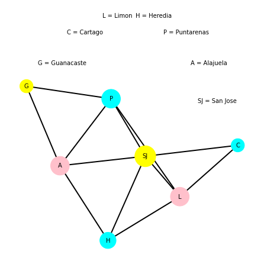

```python
import networkx as nx
import matplotlib.pyplot as plt
import sys
import warnings
warnings.filterwarnings("ignore", category=UserWarning)

test_graph = 'demo_data/CostaRica.graphml'
grapth_title = 'Mapa Costa Rica'
"""
Karla Veronica Quiros Delgado
604650870
EIF203 8am
"""
def create_colors(colr:int )->str:
    if colr == 0: return "yellow"
    if colr == 1: return "pink"
    if colr == 2: return "cyan"
    return "black"

def nx_draw(graph_path = test_graph, dim = 6, labels = True, font_size = 10, mag = 250):
    g = nx.read_graphml(graph_path)
    color = nx.greedy_color(g, "largest_first", True)
    c_list = []
    name_map = color.keys()
    for key in color:
        c_list.append(create_colors(color[key]))
    fig = plt.figure(0, figsize=(dim, dim))
    fig.canvas.set_window_title(grapth_title)
    degrees = {k:v for k,v in nx.degree(g)}
    nx.draw_kamada_kawai(g,  nodelist = color.keys(),
                       with_labels = name_map,
                       node_size  = [v * mag for v in degrees.values()],
                       font_size  = font_size,
                       node_color = c_list,
                       edge_color = "black",
                       width = 2
                       )
    plt.show()

"""que c_list queda en el mismo orden que salen los nodos en nodelist
Funcion greedy_color networkx:
Colorea un gráfico usando varias estrategias de coloración de gráficos codiciosos.
Intenta colorear un gráfico usando la menor cantidad de colores posible,
donde ningún vecino de un nodo puede tener
el mismo color que el mismo. La estrategia dada por el metodo determina el orden en que se colorean los nodos.
tiene muchos
"""

if __name__ == "__main__":
    print('Testing nx_draw Script')
    argv = sys.argv
    if len(argv) == 2:
        nx_draw(argv[1], dim=4, mag=0.5, font_size=7)
    else:
        nx_draw(test_graph)
```

### Árbol libre:

Grafo conectado con minimo número de arcos.

Para cada par de vértices hay un único camino.

Siempre debe tener n vértices y n-1 arcos.

No tiene ciclos.

Ejemplo de hacer un árbol libre

[figure not shown]

### Euler HH

Existe un cliclo de euler si todo vértice tiene grado par.

No repite arcos.

Heurística: cuando no se indica se hace alfabeticamente.

Backtracking: Devolverse, ¿devolverse o no? decidir.

Ejemplo:

[figure not shown]

### Árbol orientado:

S.T

Fijar el orden del árbol, arriba, abajo, izquierda, derecha.

Se utiliza una heurística: por ejemplo heurística alfabetica, lo cual va determinar el orden en el que realice el proceso.

Tipos:

DFS: en profundidad, es decir hacia abajo y normalmente a la izquierda.

[figure not shown]

BFS: a lo ancho, siguiendo la heuristica dada.

[figure not shown]

## Dikjstra:

Ruta por el camino mas barato

[figure not shown]

### Grafos Gn n = 1,2....Son grafos (no dirigidos) conectados que tienen cada uno n vértices y cada vértice tiene grado 2 exactamente.

a) Dibuje G1,G2,G3

b) Pruebe que todo Gn tiene un ciclo de euler de largo n para todo n >= 1

[figure not shown]

### Ciclo de Hamilton:

Usa los vértices una sola vez.

NP- Mejor solución Fuerza Bruta

Teoremas: Dirac:

G es simple y tiene por lo menos 3 vértices si, grado(v) >= | v/2 grado mayor que la mitad de cantidad de vértices. Si se cumple hay un ciclo de hamilton, si no se cumple no se puede afirmar que no hay uno.

Teorema Ore:

Gsimple |v| >= 3 conectado, para c/ par de vértices, v, w no adyacentes.

grado(v)+ grado(w) >= n

donde n = |v|

### Prim

Es un algoritmo greedy, no hace backtracking. Es similar a dijkstra

Se usa una tabla llamada PT, se utiliza para encontrar un árbol de costo minimo.

[figure not shown]

### Caminos de Euler:

Caminos que usa todos los arcos una sola vez.

Teorema: Dos vértices con grado impar únicos, entonces existe camino de euler. Puede verificar agregandole un arco a los que tienen grado impar, de "mentiras" y vera que entonces todos los vértices tienen grado par y habrá ciclo de euler. U na vez confirmado, quita los arcos agregados para probar.

### BST: Árboles binarios

Si el # es menor va a la izquierda, si es mayor va a la derecha. Puede haber máximo dos hijos por nodo.

h = altura= largo del camino mas largo de la raíz a cualquier hoja.

Árbol degenerado: esta definido por la altura, para llegar a la hoja habra que pasar por cada uno de los vértices desde la raíz hasta el que se busca (en el peor caso, la hoja).

Se necesita que h sea lo más pequeña posible. Por esta razón en un árbol binario cada nodo puede tener máximo dos hijos.

# vértices 2<sup>h+1</sup> -1

n~ O(2h)

### Ejemplo de insertar una lista de números en un árbol binario:

[figure not shown]

Nota: si se inserta una lista de números de menor a mayor o viceversa, se produciria un árbol degenerado.

### Árboles binarios de búsqueda(BST):

Árboles binarios de expresión(AST)

Caso base: Árbol núlo BT.

### Formas de recorrer un árbol

L = left

R = right

r = root

#### In- orden = en orden = In fija

Pasos: LrR

Retorna la expresión original en dado caso o los números en orden ascendente.

Ejemplo:

[figure not shown]

#### Post- order= Post fija = Polaca Inversa

Pasos : LRr

Retorna el resultado de evaluar la expresión

[figure not shown]

#### Pre order= pre fija = polaca

Pasos: rLR

[figure not shown]

### Parsing

Algoritmo de árboles de expresión

En orden: Recupera expresión.

Post order: Obtiene resultado de la expresión.

Pasos:

1) Crear el AST usando parsing

2) Recorrer post orden (imprimiendo)

3) No hace backtracking

Ejemplos con pila y expresión:

[figure not shown]

### Árbol balanceado (AVL )

Árbol que esta equilibrado, no esta más cargado de un lado que de otro.

Si la altura de la izquierda - la altura de la derecha es mayor a 1 , el árbol esta desiquilibrado.

La altura tiene que ser 0 o 1 en valor absoluto.

Pasos:

1) Inserción: inserta normal menores a la izquierda, mayores a la derecha.

2) Si se desequilibra aplica rotaciónes: simples si son recto, dobles si es sixac

Variables a utilizar:

w = último nodo inserta (hoja)

z = desde w hacia arriba el primero desequilibrado.

y = hijo de z.

x = hijo de y.

Tipos de rotaciónes simples:

SL = simple a la izquierda

SR = simple a la derecha.

Tipos de rotaciónes dobles:

Doble a la izquierda: SL y SR

Doble a la derecha: SR Y SL

Movimientos:

SI la rotación es simple y el árbol esta hacia la derecha = SL y/z

SI la rotación es simple y el árbol esta hacia la izquierda = SR y/z

SI la rotación es doble y el árbol esta en sixac hacia izquierda = 1° SL x/y, 2° SR x/z

SI la rotación es doble y el árbol esta en sixac hacia derecha = 1° SR x/y, 2° SL x/z

### Ejemplos de rotaciones en árboles AVL:

[figure not shown]

### Tiempos de corrrida: insert (x,t)

Teorema: si T es AVL - balanceado , h~ O(log(n))

1) buscar el lugar de inserción = O(log(n))

2) hacer la inserción = O(1)

3) buscar a z = O (log(n))

4) Hacer rotaciones si z existe = O(1)

```python
"""
 loriacarlos@gmail.com
 EIF203 I-2022
 Demo Binary Tree for Demo purposes
"""
class BTree: # Binary Tree
    """
        Class representing a simple Binary tree
        All logic is delegated (bypased) to BNode
        It contains a header (__header) that:
        either
            a) __header is None meaning Tree is empty
            or
            b) __header is a BNode which is the actual root of the tree
    """
    class BNode: # Binary Node
        """
        Class representing a Binary Node
        Contains minimal logic/structure required for binary  operations
        BNode has data:object (the data in node), left:BNode and right:BNode

        """
        #editado por karla Quiros, 8 am, NRC 41711
        def __init__(self, data=None, left=None, right=None):
            self.__data = data
            self.__left = left
            self.__right = right

        @property
        def data(self):
            return self.__data
        @data.setter
        def data(self, data):
            self.__data = data
        @property
        def left(self):
            return self.__left
        @left.setter
        def left(self, node):
            self.__left = node
        @property
        def right(self):
            return self.__right
        @right.setter
        def right(self, node):
            self.__right = node
        def is_leaf(self):
            return not (self.left or self.right)
        @property
        def height(self):
            def h(t):
                return 0 if t is None else t.height
            return 0 if self.is_leaf() else 1 + max(h(self.left), h(self.right))

        def __str__(self):
            return str(self.data) if self.is_leaf() else f"{self.data}({self.left}, {self.right})"

        def __repr__(self):
            return f"BNode(data={self.data}, left={self.left.__repr__()}, right={self.right.__repr__()})"
############################### BTree Body ############################
    def __init__(self, header=None, data = None):
        if header is None:
            header = BTree.BNode()
        self.__set_root(header, data)

    def root(self):
        return self.__header

    def __set_root(self, header, data=None):
        self.__header = header
        self.__header.data = data

    def is_empty(self):
        return not self.__header.left

    @property
    def data(self):
        return self.root().data

    @property
    def height(self):
        if self.is_empty(): return 0
        return self.root().left.height

    def __str__(self):
        return str(self.root().left)

    def __repr__(self):
        return repr(self.root().left)

    @property
    def left(self):
        if self.is_empty(): return None
        return self.root().left
    @left.setter
    def left(self, tree):
        assert(isinstance(tree, BTree))
        self.__header.left = tree.root()

    @property
    def right(self):
        if self.is_empty(): return None
        return self.root().right #BTree(BTree.BNode(left=self.root().right))
    @right.setter
    def right(self, tree):
        assert(isinstance(tree, BTree))
        self.__header.right= tree.root()

########################## TO DO #############################
def print_inverse_polish(Tree):
    if Tree == None:
        return "arbol vacio"
    print_inverse_polish(Tree.left)
    print_inverse_polish(Tree.right)
    print(Tree.data, end="\t")
########################## Testing ############################

def test_1():
    leafX = BTree(data="x")    # leafX = x
    leafY = BTree(data="y")    # leafY = y
    leaf666  = BTree(data=666) # leaf666 = 666

    treePlus = BTree(data='+')
    treePlus.left = leafX
    treePlus.right = leafY # treePlus = +(x, y)

    treeTimes = BTree(data='*')
    treeTimes.left = treePlus
    treeTimes.right = leaf666 # treeTimes = *(+(x, y), 666)

    mainTree = BTree(data="**")
    mainTree.left = treeTimes
    mainTree.right = treePlus # mainTree = **(*(+(x, y), 666), +(x, y))

    print(f"{mainTree=:}")
    print(f"{mainTree.height=:}") # 3

    print_inverse_polish(mainTree)
if __name__ == "__main__":
    test_1()
```

```
mainTree=*(+(x, y), 666)
mainTree.height=2
x	y	+	666	*	x	y	+	**
```

### Lenguajes y máquinas (autómatas)

Aspectos importantes:

1) Generar un lenguaje

2) Reconocer un lenguaje

3) Modelos de formas de expresión.

Necesita:

Teória de conjuntos

Lenguaje(conjunto de palabras)

Palabra (vocabulario= conjunto de objetos)

V = vocabulario

a) V = {a,b,....z}

b) V = {0,1}

Operación central = concatenación (poner cosas a la par de otras)

Epsilon = ( ε) la hilera nula x ε = ε x = x ∀ x

Propiedades :

1) x(yz) = (xy)z

2) xε = ε x = x

3) x <sup>0</sup> = ε

4) x <sup>n</sup> = x.. x .. x.....

5) x <sup>n</sup> = x * x x <sup>n-1</sup>

6) S<sup>n</sup> S<sup>m</sup> = S<sup>n +m</sup>

7) {ε}<sup>n</sup> = {ε}

8) S * = unión de S<sup>n</sup> = incluye epsilon, cerradura de kleene

9) S <sup>+</sup> = unión de S<sup>2</sup> = no incluye epsilon (al menos debe haber 1 elemento)

10) S <sup>?</sup> = unión de ε con cualquier conjunto

11) ST = concatenar

Ejemplo con vocabulario de hileras binarios

1) S * = todas las hileras binarias de 0 a 1, incluyendo epsilon

2) S <sup>+</sup> = todas las hileras binarias, no incluye epsilon (al menos debe haber 1 elemento)

3) S <sup>?</sup> = {0,1,ε}

### FA (autómata finito)

Digrafo: tiene nodos, cada nodo representa un estado y se lee una hilera.

Del estado inicial deben salir tantos arcos como elementos del conjunto.

S = estado inicial

F = estado final

Q = estados

Ejemplo autómata: Acepta 0s seguido de pares de 1s (Prácticas en JFLAP)

[figure not shown]

### Nota ejemplos de RE no a mano pero utiles:

[\t\n] = \t = tab, \n = new line

[^\t\n] = ninguno que sea vacio,\t\n

[a-z A-Z-] = letras mayusculas o minusculas

[a-z 0-9] = letras minusculas o números.

\d = [0-9] digitos

\w == [a-z A-Z 0-9-] = letras mayúsculas, minúsculas o digitos

\ \ = \ = viene un stash,scape

. = cualquier caracter - new line

### Expresiónes regulares

RS = conjuntos, ejemplo {ε}

RE = () pares, se usa | en lugar de ,

Ejemplo:

L = {01 <sup>n</sup>/ n >= 0}

¿ es una RS?

L = {0,01,01<sup>2</sup>, 01<sup>3</sup>........}

L = {0}{1}*

Al meter un elemento del vocabulario en un conjunto, se hace regular.

tal que x = {0} es RS

y = {1} * = z * es RS

tal que z = {1} es RS

por lo que xy = RS

### Ejemplo de conjunto NO regular

L = {0<sup>n</sup> 1<sup>n</sup> / n>= 0}

L = {ε,01,0<sup>2</sup>1<sup>2</sup>, 0<sup>3</sup>1<sup>3</sup>........}

El crecimiento de 0 va ir siendo igual al 1 por lo que el autómata no podra manejar infinitas soluciones para ambos, lo cual le hace irregular.

### Ejemplo SI regular

L = {0<sup>n</sup> 1<sup>n</sup> / n<=666}

Este ejemplo es RE aunque 0 y 1 vayan elevados a la n ya que existe un limite establecido.

### Ejemplos de RE y autómatas

L = {0<sup>n</sup> 1<sup>m</sup>/n>= 0,m>= 0}

RS = {0}* {1} *

RE = 0 * 1* admite epsilon

[figure not shown]

Hileras binarias con al menos un 1

V ={0,1}

RS = {0}* 1<sup>+</sup> {0,1}*

RE = 0* 1<sup>+</sup> (0|1)*

[figure not shown]

Tabla de estados

[figure not shown]

### Final de apuntes

Apuntes por : Karla Verónica Quiros Delgado, basados en notas de clases (resumen)

Imagenes de ilustraciones: creados por Karla Quiros, basadas en apuntes de clases y prácticas. Creado en draw.io y autómatas creados en JFLAP.